# Team

Tyren Teav

4/16/2021

Problem 1:

Saturdays have the most accidents than any other day of the week, followed by Sunday which makes sense. Weekends the most things are going on, people are going out the most, likely the most activity.

```r
library(ggplot2)
library(tidyverse)
acc <- read.csv("https://raw.githubusercontent.com/xdaiISU/ds202materials/master/hwlabs/fars2017/accident.csv", stringsAsFactors = FALSE)

per <- read.csv("https://raw.githubusercontent.com/xdaiISU/ds202materials/master/hwlabs/fars2017/person.csv", stringsAsFactors = FALSE)

acc %>%
  group_by(acc$DAY_WEEK) %>%
  summarize(
    count = length(DAY_WEEK)
  ) %>%
  arrange(count)
```

```
## # A tibble: 7 x 2
##   `acc$DAY_WEEK` count
##            <int> <int>
## 1              4  4314
## 2              3  4347
## 3              2  4374
## 4              5  4621
## 5              6  5358
## 6              1  5360
## 7              7  5873
```

Problem 2

```r
injury <- subset(per, INJ_SEV >= 1)
head(injury)
```

```
##   STATE ST_CASE VE_FORMS VEH_NO PER_NO STR_VEH COUNTY DAY MONTH HOUR MINUTE
## 1     1   10001        1      1      1       0     73  19     2   23     35
## 2     1   10002        1      1      1       0     89  14     2   14     59
## 4     1   10003        3      2      1       0    101  31     1   20     31
## 6     1   10004        1      1      1       0     73   1     1   16     55
## 7     1   10005        1      1      1       0     13   1     1   20      0
## 8     1   10005        1      1      2       0     13   1     1   20      0
##   RUR_URB FUNC_SYS HARM_EV MAN_COLL SCH_BUS MAKE MAK_MOD BODY_TYP MOD_YEAR
## 1       2        1      38        0       0   20   20421       15     2004
## 2       2        1       1        0       0   37   37402       14     2005
## 4       2        1      12        1       0    2    2404       14     2003
## 6       2        4      30        0       0   30   30046        4     2014
## 7       1        1      35        0       0   12   12471       34     2010
## 8       1        1      35        0       0   12   12471       34     2010
##   TOW_VEH SPEC_USE EMER_USE ROLLOVER IMPACT1 FIRE_EXP AGE SEX PER_TYP INJ_SEV
```

[output cut: 41 more lines]

Problem 3 I used INJ_SEV like problem 2 to represent the fatalities

```r
library(dplyr)


per2 <- per %>%
  group_by(STATE, MAKE) %>%
  summarize(
    deaths = sum(INJ_SEV)
  ) %>%
  arrange(STATE)
per3 <- na.omit(per2)

per4 <- per3 %>%
  group_by(STATE) %>%
  top_n(1,deaths)

per4
```

```
## # A tibble: 52 x 3
## # Groups:   STATE [51]
##    STATE  MAKE deaths
##    <int> <int>  <int>
##  1     1    12    750
##  2     2    20     74
##  3     4    20    595
##  4     5    20    486
##  5     6    49   2385
##  6     8    12    394
##  7     9    37    158
##  8    10    37     70
##  9    11    37     30
## 10    12    12   1724
## # … with 42 more rows
```

Problem 4

The most dangerous vehicle is described as the vehicle make that has caused the most INJ_SEV from problem 2 and 3. The map shows that there are two main makes that have cause the most deaths, being ,make 20 and 12.

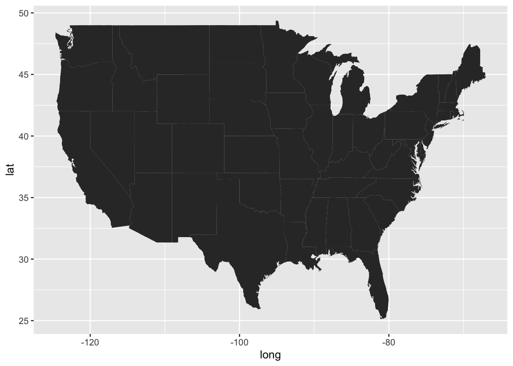

```r
library(readxl)
library(tidyverse)
states <- map_data('state')
US <- readxl::read_xlsx("/Users/Tyren/Desktop/DS_202/United_States.xlsx")
ggplot(states, aes(x = long, y = lat)) + geom_polygon(aes(group=group))
```

```r
US$`State Name` <- tolower(US$`State Name`)
text <- full_join(US, states, by = c("State Name" = "region"))

text1 <- select(text, "State Name", "State Code", "long", "lat")

per4$STATE = as.character(per4$STATE)

locations <- text1 %>%
  group_by(`State Name`, `State Code`) %>%
  summarize(
    long = mean(long),
    lat = mean(lat)
  )
```

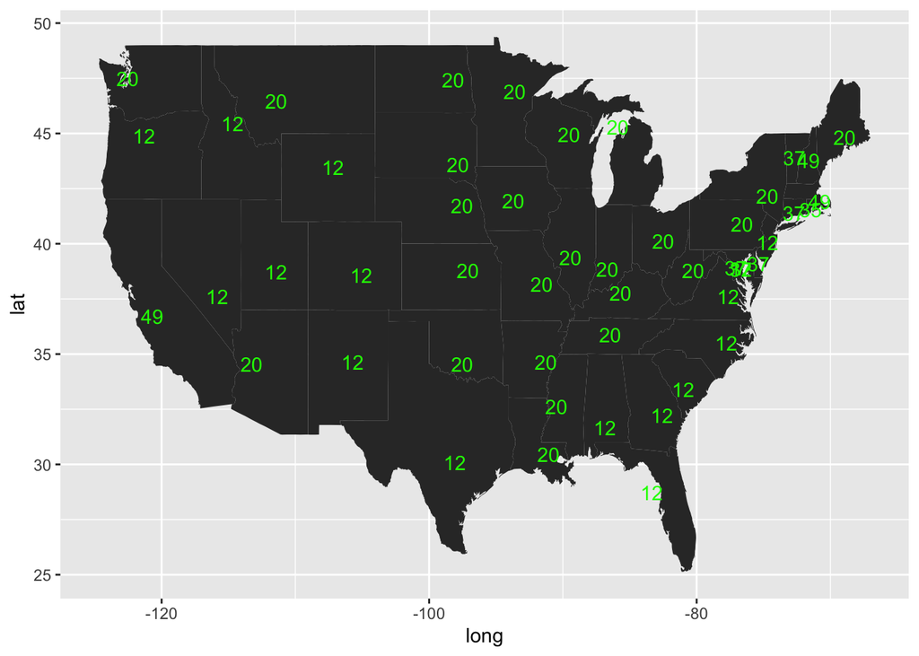

```r
text2 <- full_join(locations, per4, by = c('State Code' = "STATE"))

ggplot(states, aes(x=long, y = lat)) + geom_polygon(aes(group=group)) + geom_text(aes(label= MAKE), data = text2, color = "Green")
```

```r
acc <- read.csv("https://raw.githubusercontent.com/xdaiISU/ds202materials/master/hwlabs/fars2017/accident.csv", stringsAsFactors = FALSE)
pers <- read.csv("https://raw.githubusercontent.com/xdaiISU/ds202materials/master/hwlabs/fars2017/person.csv", stringsAsFactors = FALSE)
```

```r
glc <- readxl::read_xlsx("/Users/Tyren/Desktop/DS_202/United_States.xlsx")
```

Question 5

```r
accidents <-inner_join(pers, acc, by = c("STATE", "ST_CASE", "HOUR"))
```

Question 6

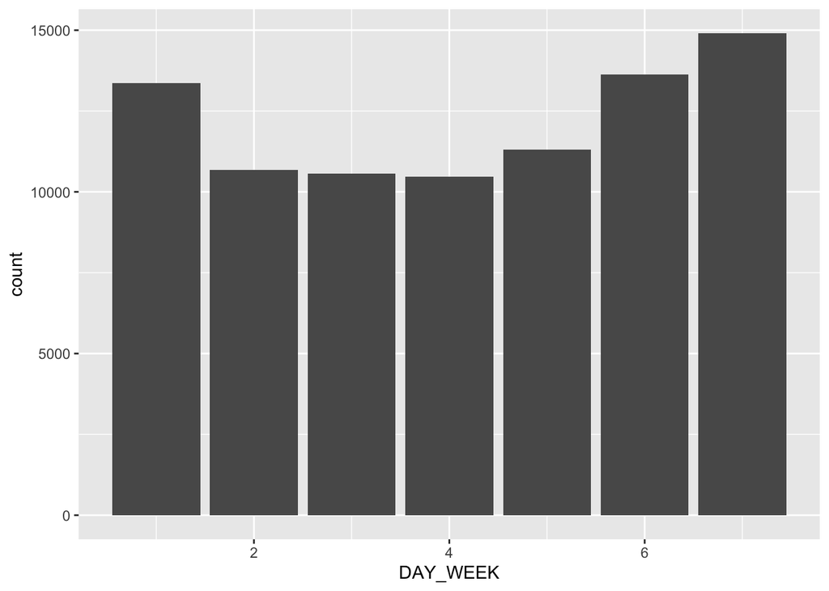

```r
tally1 <- accidents %>%
  group_by(DAY_WEEK) %>%
  summarize(DayCount = n())

ggplot(tally1, aes(x = DAY_WEEK, weight = DayCount, fill = DAY_WEEK)) + geom_bar()
```